# 5. Building the maps

Jessica Hintzsche

2026-01-23

```r
library(ggplot2)
library(ggpubr)
library(tidyverse)
```

```r
# make list of file names for files containing map data - e.g., 4_4_fam9_male_LG1
maps.male_FAM9 <- list.files(path = "4_orderMarkers/FAM9",
                  pattern = glob2rx(pattern="4_4_fam_FAM9_male_LG*"),
                  full.names = TRUE)

# name each file according to the linkage group it belongs to

names(maps.male_FAM9) <- c("1","10","11","12","13", "14", "15", "16", "17", "18", "19", "2", "20", "21", "22", "23", "24", "3","4","5","6","7","8","9")

# this lapply loop reads the individual tab-delimited files into a list
maps.male_FAM9 <- lapply(maps.male_FAM9, function(m) {
    read_delim(m, delim = "\t",
               skip = 4,
               col_names = c("ID","male","female"))
})

# this mapply loops iterates over the list of dataframes from the previous step and their LG numbers
# it adds a column to each dataframe containing info on the LG number
maps.male_FAM9 <- mapply(function(z,w) {
  z <- z %>% select(ID,male,female)

  z %>% mutate("LG" = w)
}, maps.male_FAM9, names(maps.male_FAM9), SIMPLIFY = FALSE)

# now that each dataframe has data on map position, SNPID and LG, we can bind them all together for each family
maps.male_FAM9 <- do.call("rbind", maps.male_FAM9)
```

Then for the female map

```r
# make list of file names for files containing map data - e.g., 4_4_fam9_male_LG1
maps.female_FAM9 <- list.files(path = "4_orderMarkers/FAM9",
                  pattern = glob2rx(pattern="4_4_fam_FAM9female_LG*"),
                  full.names = TRUE)

# name each file according to the linkage group it belongs to
names(maps.female_FAM9) <- c("1","10","11","12","13", "14", "15", "16", "17", "18", "19", "2", "20", "21", "22", "23", "24", "3","4","5","6","7","8","9")

# this lapply loop reads the individual tab-delimited files into a list
maps.female_FAM9 <- lapply(maps.female_FAM9, function(m) {
    read_delim(m, delim = "\t",
               skip = 4,
               col_names = c("ID","male","female"))
})

# this mapply loops iterates over the list of dataframes from the previous step and their LG numbers
# it adds a column to each dataframe containing info on the LG number
maps.female_FAM9 <- mapply(function(z,w) {
  z <- z %>% select(ID,male,female)

  z %>% mutate("LG" = w)
}, maps.female_FAM9, names(maps.female_FAM9), SIMPLIFY = FALSE)

# now that each dataframe has data on map position, SNPID and LG, we can bind them all together for each family
maps.female_FAM9 <- do.call("rbind", maps.female_FAM9)
```

Lets look at the dataframe:

```r
head(maps.male_FAM9)
```

```
## # A tibble: 6 × 4
##      ID  male female LG
##   <dbl> <dbl>  <dbl> <chr>
## 1  4352 0.538      0 1
## 2  4323 0.538      0 1
## 3  4112 0.538      0 1
## 4  4264 0.728      0 1
## 5  4243 0.728      0 1
## 6  4345 0.728      0 1
```

```r
tail(maps.male_FAM9)
```

```
## # A tibble: 6 × 4
##      ID  male female LG
##   <dbl> <dbl>  <dbl> <chr>
## 1 32673  51.8   53.8 9
## 2 49968  52.2   53.8 9
## 3 32562  52.4   53.8 9
## 4 32494  52.4   53.8 9
## 5 32415  52.6   53.8 9
## 6 32864  52.6   53.8 9
```

```r
head(maps.female_FAM9)
```

```
## # A tibble: 6 × 4
##      ID  male female LG
##   <dbl> <dbl>  <dbl> <chr>
## 1  1971 0.207  0.205 1
## 2  1954 0.28   0.205 1
## 3  1930 0.28   0.205 1
## 4  1942 0.28   0.205 1
## 5  1921 0.28   0.205 1
## 6  1933 0.28   0.205 1
```

```r
tail(maps.female_FAM9)
```

```
## # A tibble: 6 × 4
##      ID  male female LG
##   <dbl> <dbl>  <dbl> <chr>
## 1 49168  50.4   46.4 9
## 2 49552  50.4   46.4 9
## 3 50131  50.4   46.4 9
## 4 49869  50.5   46.4 9
## 5 49836  50.5   46.4 9
## 6 49399  50.5   46.5 9
```

Let’s full_join these two, retaining only the sex specific map we requested each time.

```r
X <- maps.female_FAM9 %>% select(ID,LG,female)
Y <- maps.male_FAM9 %>% select(ID,LG,male)

maps_FAM9 <- full_join(X, Y, by = c("ID", "LG"),
                 keep = FALSE)

rm(maps.female_FAM9, maps.male_FAM9, X, Y)
```

Unfortunately LepMap converts marker IDs to sequential numbers. Let’s retrieve the original marker IDs from the `Filtering2` output.

```r
# read Filtering2 output
snpids <- read_delim("2_filtered/2_2_filtered_Lepmap_family_FAM9_default",
                delim = "\t",skip = 7,
                col_names = "SNPID")
# add column with sequential ids from 1 to nrow
snpids <- snpids %>% add_column("ID" = seq(1:nrow(snpids)))
head(snpids)
```

```
## # A tibble: 6 × 1,973
##   SNPID  X2    X3    X4    X5    X6    X7    X8    X9    X10   X11   X12   X13
##   <chr>  <chr> <chr> <chr> <chr> <chr> <chr> <chr> <chr> <chr> <chr> <chr> <chr>
## 1 Lca_1… POS   1.0 … 1.0 … 1.0 … 1.0 … 1.0 … 1.0 … 0 1.… 1.0 … 1.0 … 1.0 … 0 1.…
## 2 Lca_1… POS   1.0 … 1.0 … 1.0 … 1.0 … 1.0 … 1.0 … 1.0 … 1.0 … 1.0 … 1.0 … 0 1.…
## 3 Lca_1… POS   1.0 … 1.0 … 0 0 … 0 1.… 0 1.… 0 0 … 0 1.… 0 0 … 0 1.… 0 0 … 0 1.…
## 4 Lca_1… POS   1.0 … 1.0 … 1.0 … 1.0 … 0 1.… 0 1.… 1.0 … 0 1.… 0 1.… 0 1.… 1.0 …
## 5 Lca_1… POS   0 1.… 0 1.… 0 0 … 0 0 … 0 1.… 0 1.… 0 0 … 0 1.… 0 1.… 0 1.… 1.0 …
## 6 Lca_1… POS   1.0 … 1.0 … 1.0 … 0 1.… 0 1.… 0 1.… 1.0 … 0 1.… 0 0 … 0 1.… 0 1.…
## # ℹ 1,960 more variables: X14 <chr>, X15 <chr>, X16 <chr>, X17 <chr>,
## #   X18 <chr>, X19 <chr>, X20 <chr>, X21 <chr>, X22 <chr>, X23 <chr>,
## #   X24 <chr>, X25 <chr>, X26 <chr>, X27 <chr>, X28 <chr>, X29 <chr>,
## #   X30 <chr>, X31 <chr>, X32 <chr>, X33 <chr>, X34 <chr>, X35 <chr>,
## #   X36 <chr>, X37 <chr>, X38 <chr>, X39 <chr>, X40 <chr>, X41 <chr>,
## #   X42 <chr>, X43 <chr>, X44 <chr>, X45 <chr>, X46 <chr>, X47 <chr>,
## #   X48 <chr>, X49 <chr>, X50 <chr>, X51 <chr>, X52 <chr>, X53 <chr>, …
```

The first column is the true SNP IDs from the SNP array, the ID column is the sequential ID given by LepMap. Join this to our map

```r
#join
maps_FAM9 <- left_join(maps_FAM9, snpids, by="ID")

#re-arrange
maps_FAM9 <- maps_FAM9 %>% select(SNPID, ID, LG, male, female)
```

```r
#create emtpy tibble
temp <- tibble(
  SNPID = character(),
  ID = double(),
  LG = factor(),
  male = double(),
  female = double()
  )

#loop through linkage groups
for (i in 1:24) {
  #retain one linkage group
  y <- maps_FAM9 %>% filter(LG == i)
  #find max value for female linkage map
  my.max <- max(y$female, na.rm = TRUE)

  #if covariance is negative (inversely correlated)
  if (cov(y$male, y$female,
          use = "pairwise.complete.obs") < 0) {
    #modify female map to be inverted
    z <- y %>%
      mutate(female = case_when(
        female >= 0 ~ (my.max-female),
        TRUE ~ female
        ))
    #add to dataframe
    temp <- bind_rows(temp,z)
    }
  #if covariance is positive
  else {
    #bind orignal non-modified dataframe
    temp <- bind_rows(temp,y)
  }
}

#rename
old.maps_FAM9 <- maps_FAM9
maps_FAM9 <- temp

#remove unnecessary intermediate files
rm(temp,y,z,i,my.max)
```

Save the new maps in 5_maps:

```r
write_delim(maps_FAM9, file = "5_maps/5_1_fam_FAM9_linkageMap_chrom1_24.txt",
            delim = "\t",col_names = T)
```

### 4.4. Plot male versus female maps

A very good way to both assess the quality of a map, troubleshoot, and gain the first biological insights for your species is to plot the male and female maps against each other.

First, let’s do one final tidy up

```r
old.maps_FAM9 <- old.maps_FAM9 %>% mutate(LG = fct_relevel(LG, "1", "2", "3", "4", "5", "6", "7", "8","9","10","11","12","13","14","15","16","17","18","19","20","21","22","23","24"))

maps_FAM9 <- maps_FAM9 %>% mutate(LG = fct_relevel(LG, "1", "2", "3", "4", "5", "6", "7", "8","9","10","11","12","13","14","15","16","17","18","19","20","21","22","23","24"))
```

Looking at a single LG

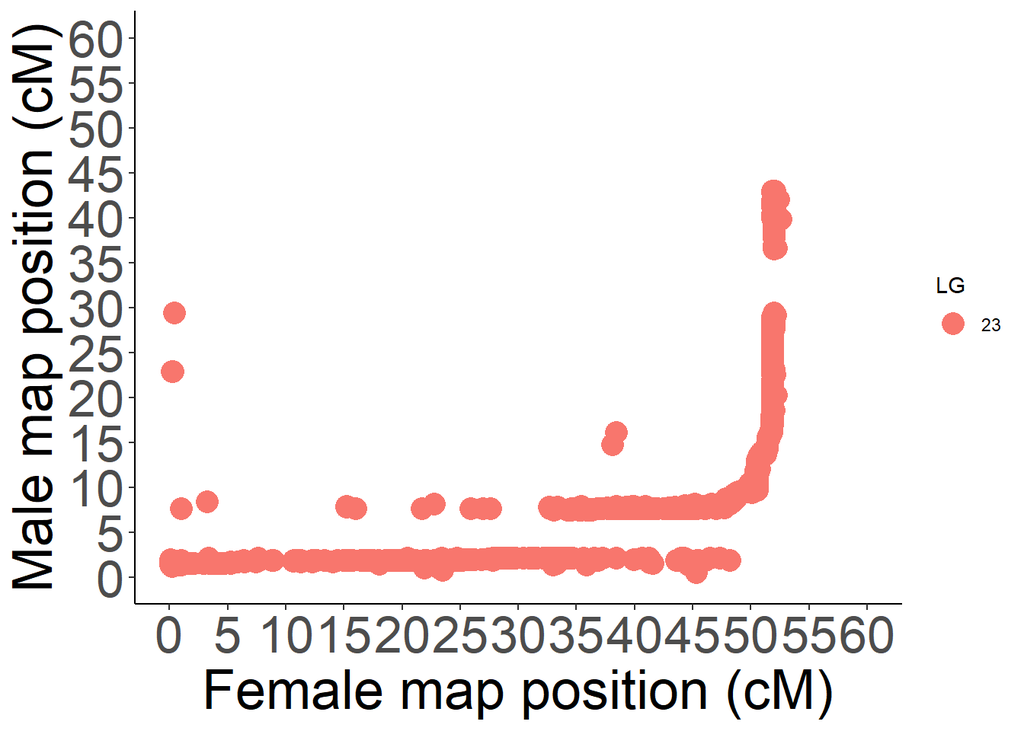

```r
p5_FAM9 <- ggplot(maps_FAM9 %>% filter(LG==23),
             aes(x=female, y=male,
                 group = LG, colour = LG)) +
  geom_point(size=5) + theme_classic() +
  scale_y_continuous(limits = c(0, 60),
                     breaks = seq(0, 60, by = 5)) +
  scale_x_continuous(limits = c(0,60),
                     breaks = seq(0, 60, by = 5)) +
  labs(y = "Male map position (cM)", x = "Female map position (cM)")+
  theme(
    axis.title = element_text(size = 27),
    axis.text = element_text(size = 25)
  )


p5_FAM9
```

Plotting each LG individually in a facet wrap (rainbow worms)

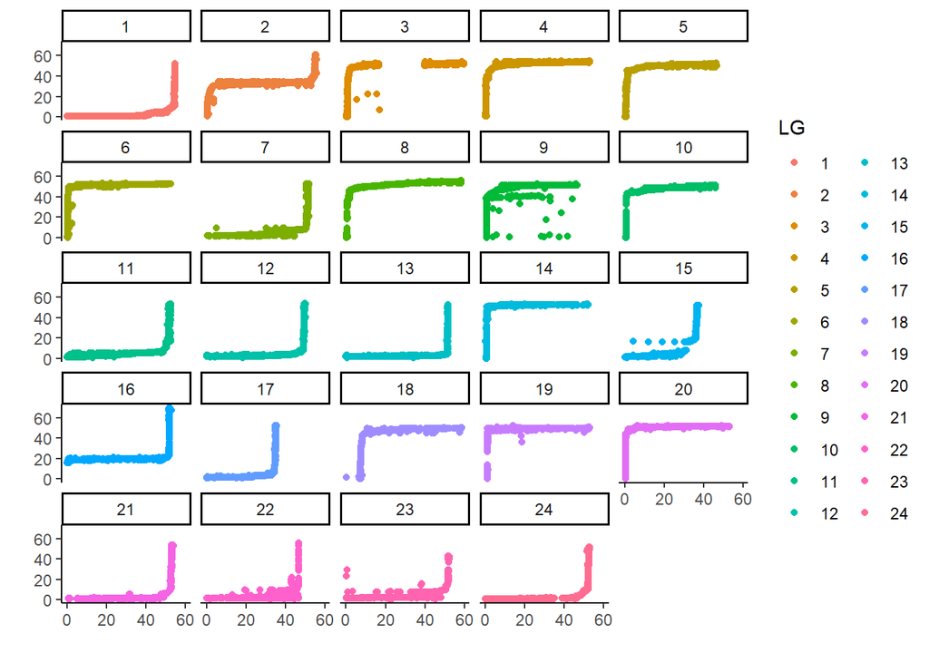

```r
# Remove any row with NAs
# these are the rows that include markers mapped only in the male or female map
# Thus, we will only be mapping markers heterozygous for both parents
maps.NA_FAM9 <- maps_FAM9 %>% drop_na()

# Plot the resulting data
p4_FAM9 <- ggplot(maps.NA_FAM9, aes(x=female, y=male,
                          group = LG, colour = LG)) +
  #facet by Linkage group
  geom_point() + facet_wrap(~LG, ncol = 5) +
  ylab("") + xlab("") +
  theme(strip.background = element_blank(),
        strip.text.x = element_blank()) +
  theme_classic()

ggsave("5_maps/5_fam_FAM9_rainbowworms.png", plot=p4_FAM9, width = 12, height =7, units = "in")
p4_FAM9
```

chromosome order

```r
maps.phys <- read.delim("barra52KCRCP.bim",
                      header= FALSE,
                      sep = "\t",)
```

```r
maps.phys <- select(maps.phys, -V3, -V5, -V6)
colnames(maps.phys) <-  c("CHR", "SNPID", "bp")
test.merge <- merge.data.frame(maps_FAM9, maps.phys, by="SNPID", all.x = TRUE)
```

Check to make sure it works

```r
test.merge[test.merge$SNPID == "Lca_1_RAD_Asia_267881", ]
```

```
##                   SNPID    ID LG   male female CHR       bp
## 1 Lca_1_RAD_Asia_267881 17171 19 49.014     NA   9 16305194
```

```r
maps_FAM9[maps_FAM9$SNPID == "Lca_1_RAD_Asia_267881", ]
```

```
## # A tibble: 1 × 5
##   SNPID                    ID LG     male female
##   <chr>                 <dbl> <fct> <dbl>  <dbl>
## 1 Lca_1_RAD_Asia_267881 17171 19     49.0     NA
```

```r
maps.phys[maps.phys$SNPID == "Lca_1_RAD_Asia_267881", ]
```

```
##       CHR                 SNPID       bp
## 17839   9 Lca_1_RAD_Asia_267881 16305194
```

```r
test.merge[test.merge$SNPID == "Lca_10251_WGS_AUE_snpa", ]
```

```
##                      SNPID    ID LG   male female CHR       bp
## 203 Lca_10251_WGS_AUE_snpa 29825  5 50.368 20.366  15 25214020
```

```r
maps_FAM9[maps_FAM9$SNPID == "Lca_10251_WGS_AUE_snpa", ]
```

```
## # A tibble: 1 × 5
##   SNPID                     ID LG     male female
##   <chr>                  <dbl> <fct> <dbl>  <dbl>
## 1 Lca_10251_WGS_AUE_snpa 29825 5      50.4   20.4
```

```r
maps.phys[maps.phys$SNPID == "Lca_10251_WGS_AUE_snpa", ]
```

```
##       CHR                  SNPID       bp
## 30912  15 Lca_10251_WGS_AUE_snpa 25214020
```

rename the map

```r
merged.FAM9.maps <- test.merge
rm(test.merge)
```

Here I am looking for rearrangements between the genome and these maps

```r
# Replace 'merged.maps' with the with another name in case things get weird.
df <- merged.FAM9.maps

# Group by LG and summarise to find the most common CHR for each LG
most_common <- df %>%
  group_by(LG) %>%
  summarise(most_common_chr = names(which.max(table(CHR))))

# Join the most common CHR back to the original dataframe
df <- df %>%
  left_join(most_common, by = "LG")

# Create a new column to identify the CHR values that do not match the most common value
df <- df %>%
  mutate(not_most_common = ifelse(CHR != most_common_chr, CHR, NA))

# Print the dataframe
head(df)
```

```
##                    SNPID    ID LG   male female CHR       bp most_common_chr
## 1  Lca_1_RAD_Asia_267881 17171 19 49.014     NA   9 16305194               9
## 2 Lca_10000_WGS_AUE_snpa 30039  5 50.983 24.418  15 27553826              15
## 3 Lca_10001_WGS_AUE_snpa 30038  5 50.983 24.470  15 27545607              15
## 4 Lca_10002_WGS_AUE_snpa 30037  5 50.983 24.470  15 27537957              15
## 5 Lca_10003_WGS_AUE_snpa 30036  5 50.983 24.470  15 27528390              15
## 6 Lca_10004_WGS_AUE_snpa 30035  5 50.983 24.418  15 27524413              15
##   not_most_common
## 1              NA
## 2              NA
## 3              NA
## 4              NA
## 5              NA
## 6              NA
```

Plotting each LG individually in chrom order in a facet wrap (rainbow worms)

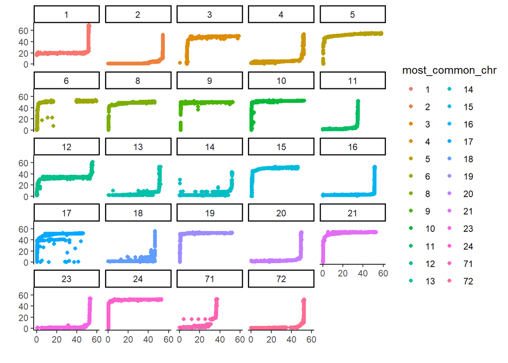

```r
# Remove any row with NAs
# these are the rows that include markers mapped only in the male or female map
# Thus, we will only be mapping markers heterozygous for both parents
#df <- df %>% drop_na()
 df <- df |>  mutate(most_common_chr = as.factor(most_common_chr))
df_FAM9 <- df %>% mutate(most_common_chr = fct_relevel(most_common_chr, "1", "2", "3", "4", "5", "6", "8","9","10","11","12","13","14","15","16","17","18","19","20","21","23","24", "71", "72"))
rm(df)
# Plot the resulting data
pFAM9 <- ggplot(df_FAM9, aes(x=female, y=male,
                          group = most_common_chr, colour = most_common_chr)) +
  #facet by Linkage group
  geom_point() + facet_wrap(~most_common_chr, ncol = 5) +
  ylab("") + xlab("") +
  theme(strip.background = element_blank(),
        strip.text.x = element_blank()) +
  theme_classic()

ggsave("5_maps/5_5_fam_FAM9_rainbowworms_chrom_order.png", plot=pFAM9, width = 12, height =7, units = "in")
pFAM9
```